You may use this notebook for your project or you may develop your project on your own machine. Either way, be sure to submit all your code to Vocareum via this notebook or upload any code used for your project as a part of the sumbission.

If you intend to use this notebook for your report (pdf) submission; be sure to look into markdown text for any discussion you need: [Jupyter Documentation](https://jupyter-notebook.readthedocs.io/en/stable/examples/Notebook/Working%20With%20Markdown%20Cells.html)

# Reading all the csv files and combing into a database

```python
import pandas as pd
import numpy as np
import matplotlib.pyplot as plt
import seaborn as sns
import matplotlib.ticker as mtick
import re
import time
sns.set()
#
action_movie = pd.read_csv('action.csv')
crime_movie = pd.read_csv('crime.csv')
adventure_movie = pd.read_csv('adventure.csv')
thriller_movie = pd.read_csv('thriller.csv')
family_movie = pd.read_csv('family.csv')
mystery_movie = pd.read_csv('mystery.csv')
scifi_movie = pd.read_csv('scifi.csv')
history_movie = pd.read_csv('history.csv')
sports_movie = pd.read_csv('sports.csv')
animation_movie = pd.read_csv('animation.csv')
war_movie = pd.read_csv('war.csv')
biography_movie = pd.read_csv('biography.csv')
horror_movie = pd.read_csv('horror.csv')
fantasy_movie = pd.read_csv('fantasy.csv')
romance_movie = pd.read_csv('romance.csv')
film_noir_movie = pd.read_csv('film-noir.csv')

# Add genre column to each dataframe
action_movie['genre'] = 'Action'
crime_movie['genre'] = 'Crime'
adventure_movie['genre'] = 'Adventure'
thriller_movie['genre'] = 'Thriller'
family_movie['genre'] = 'Family'
mystery_movie['genre'] = 'Mystery'
scifi_movie['genre'] = 'Sci-Fi'
history_movie['genre'] = 'History'
sports_movie['genre'] = 'Sports'
animation_movie['genre'] = 'Animation'
war_movie['genre'] = 'War'
biography_movie['genre'] = 'Biography'
horror_movie['genre'] = 'Horror'
fantasy_movie['genre'] = 'Fantasy'
romance_movie['genre'] = 'Romance'
film_noir_movie['genre'] = 'Film-Noir'
# Concatenate all dataframes
df = pd.concat([action_movie, crime_movie, adventure_movie, thriller_movie,
                family_movie, mystery_movie, scifi_movie, history_movie,
                sports_movie, animation_movie, war_movie, biography_movie,
                horror_movie, fantasy_movie, romance_movie, film_noir_movie])

# Reset index
df = df.reset_index(drop=True)

# Preview the dataframe
#df
```

# Cleaning the Data

Remove unwanted values not needed for evaluation. Preparing and formatting the dataframe.

```python
# copy of the DataFrame to avoid SettingWithCopyWarning if slicing is used earlier
df = df.copy()

# Remove unwanted year values
unwanted_values = ['I', 'II', 'V', 'III', 'VII', 'IV', 'XXIII', 'IX', 'XV', 'VI', 'X', 'XIV', 'XIX', 'XXIX', 'XXI', 'VIII', 'XI', 'XVIII', 'XII', 'XIII', 'LXXI', 'XVI', 'XX', 'XXXIII', 'XXXII', 'XXXVI', 'XVII', 'LXIV', 'LXII', 'LXVIII', 'XL', 'XXXIV', 'XXXI', 'XLV', 'XLIV', 'XXIV', 'XXVII', 'LX', 'XXV', 'XXXIX', '2029', 'XXVIII', 'XXX', 'LXXII', '1909', 'XXXVIII', 'XXII', 'LVI', 'LVII', 'XLI', 'LII', 'XXXVII', 'LIX', 'LVIII', 'LXX', 'XLIII', 'XLIX', 'LXXIV', 'XXVI', 'C', 'XLI', 'LVII', 'LV', 'XLVI', 'LXXVII', 'XXXV', 'LIV', 'LI', 'LXXXII', 'XCIX', 'LXIII']
df = df[~df['year'].isin(unwanted_values)]

# Fill NaN values and handle data types directly using .loc for safer operations
df.loc[:, 'year'] = df['year'].fillna(0).astype(int)
df.loc[:, 'year'] = df.loc[:, 'year'].replace(0, np.nan)

# Drop rows with NaN values in 'year' column safely
df.dropna(subset=['year'], inplace=True)

# Convert 'year' back to integer, ensure it's done in the DataFrame
df.loc[:, 'year'] = df['year'].astype(int)

# Drop the 'movie_id' column
df = df.drop(columns=['movie_id'])
df = df.drop(columns=['director_id'])
df = df.drop(columns=['star_id'])

# Display the DataFrame
#df
df_copy = df
#df
```

## Format the runtimes

```python
# Drop rows where 'runtime' is NaN
df = df.dropna(subset=['runtime'])

# operate on a copy to avoid SettingWithCopyWarning if df is derived from another DataFrame
df = df.copy()

# Convert all 'runtime' entries to string and replace unwanted characters using .loc for safe operations
df.loc[:, 'runtime'] = df['runtime'].astype(str).str.replace('min', '', regex=False)
df.loc[:, 'runtime'] = df.loc[:, 'runtime'].str.replace(',', '', regex=False)

# Convert the cleaned 'runtime' strings to integers using .loc for direct modification
df.loc[:, 'runtime'] = df['runtime'].astype(int)

# Convert 'runtime' from integer minutes to timedelta using .loc for direct modification
df.loc[:, 'runtime'] = pd.to_timedelta(df['runtime'], unit='m')

# Print DataFrame to confirm changes
#df
```

## Format the names of actors

```python
# First, ensure all entries in 'star' are strings (convert NaNs to an empty string or a placeholder)
df['star'] = df['star'].astype(str)

# Replace newlines and extra spaces
df['star'] = df['star'].str.replace('\n', ', ', regex=False)  # Replace newlines with commas
df['star'] = df['star'].str.replace(',  ', ', ', regex=False)  # Clean up potential double spaces

# Strip whitespace from each name and rejoin with clean commas
df['star'] = df['star'].apply(lambda x: ', '.join(name.strip() for name in x.split(',')))

# Split 'star' into individual names and explode into rows
star_list = df['star'].str.split(', ').explode()

# Count occurrences of each star
star_counts = star_list.value_counts()

# Convert to DataFrame for better manipulation and storage
star_counts_df = star_counts.reset_index()
star_counts_df.columns = ['Star Name', 'Occurrences']
#Drop if blank or nan and reindex
star_counts_df = star_counts_df[(star_counts_df['Star Name'].str.strip() != '') & (star_counts_df['Star Name'] != 'nan')]
star_counts_df.reset_index(drop=True, inplace=True)

# Display the resulting DataFrame
#print(star_counts_df.head())
#df
```

# The dataframe that we are working with

```python
df
```

|  | movie_name | year | certificate | runtime | genre | rating | description | director | star | votes | gross(in $) |
| --- | --- | --- | --- | --- | --- | --- | --- | --- | --- | --- | --- |
| 0 | Black Panther: Wakanda Forever | 2022 | PG-13 | 0 days 02:41:00 | Action | 6.9 | The people of Wakanda fight to protect their h... | Ryan Coogler | Letitia Wright, , Lupita Nyong'o, , Danai Guri... | 204835.0 | NaN |
| 1 | Avatar: The Way of Water | 2022 | PG-13 | 0 days 03:12:00 | Action | 7.8 | Jake Sully lives with his newfound family form... | James Cameron | Sam Worthington, , Zoe Saldana, , Sigourney We... | 295119.0 | NaN |
| 2 | Plane | 2023 | R | 0 days 01:47:00 | Action | 6.5 | A pilot finds himself caught in a war zone aft... | Jean-François Richet | Gerard Butler, , Mike Colter, , Tony Goldwyn, ... | 26220.0 | NaN |
| 3 | Everything Everywhere All at Once | 2022 | R | 0 days 02:19:00 | Action | 8.0 | A middle-aged Chinese immigrant is swept up in... | Dan Kwan, \nDaniel Scheinert | Michelle Yeoh, , Stephanie Hsu, , Jamie Lee Cu... | 327858.0 | NaN |
| 5 | Ant-Man and the Wasp: Quantumania | 2023 | PG-13 | 0 days 02:05:00 | Action | 6.6 | Scott Lang and Hope Van Dyne, along with Hank ... | Peyton Reed | Paul Rudd, , Evangeline Lilly, , Jonathan Majo... | 5396.0 | NaN |
| ... | ... | ... | ... | ... | ... | ... | ... | ... | ... | ... | ... |
| 368295 | Black Diamonds | 1940 | NaN | 0 days 01:00:00 | Film-Noir | 5.5 | A reporter on a visit to his hometown hears of... | Christy Cabanne | Richard Arlen, , Andy Devine, , Kathryn Adams,... | 33.0 | NaN |
| 368296 | The Gentleman from Louisiana | 1936 | NaN | 0 days 01:07:00 | Film-Noir | 4.5 | In Victorian-era USA, a horse-jockey becomes a... | Irving Pichel | Eddie Quillan, , Charles 'Chic' Sale, , Charlo... | 21.0 | NaN |
| 368297 | El cerco | 1955 | NaN | 0 days 01:17:00 | Film-Noir | 6.2 | A group of robbers assault a factory in the po... | Miguel Iglesias | José Guardiola, , Isabel de Castro, , Ángel Jo... | 46.0 | NaN |
| 368298 | Three Silent Men | 1940 | NaN | 0 days 01:12:00 | Film-Noir | 5.0 | Foreign scientist is selling a secret weapon t... | Thomas Bentley | Sebastian Shaw, , Derrick De Marney, , Patrici... | 79.0 | NaN |
| 368299 | Destination Big House | 1950 | NaN | 0 days 01:00:00 | Film-Noir | 6.3 | School teacher Janet Brooks innocently involve... | George Blair | Dorothy Patrick, , Robert Rockwell, , Jimmy Ly... | 40.0 | NaN |

254475 rows × 11 columns

## Clean and store the directors column by occurrence

```python
# Clean the 'director' column by replacing newlines with ', '
df['director'] = df['director'].str.replace('\n', ', ', regex=False)

# Clean any potential double spaces just in case
df['director'] = df['director'].str.replace(',  ', ', ', regex=False)

# Split 'director' into individual names and explode into rows
director_list = df['director'].str.split(', ').explode()

# Count occurrences of each director
director_counts = director_list.value_counts()

# Convert to DataFrame for better manipulation and storage
director_counts_df = director_counts.reset_index()
director_counts_df.columns = ['Director Name', 'Occurrences']

director_counts_df = director_counts_df[(director_counts_df['Director Name'].str.strip() != '')]
director_counts_df.reset_index(drop=True, inplace=True)

# Display the resulting DataFrame
#print(director_counts_df.head())
```

## Clean and store popular genres over time by year

```python
# Ensure the data types are correct
df['year'] = df['year'].astype(int)
df['genre'] = df['genre'].astype(str)

# Initialize a new DataFrame to store the results
popular_genres = pd.DataFrame(columns=['year', 'popular_genre', 'number_of_release'])
popular_genres_filtered = popular_genres[~popular_genres['year'].isin([2025, 2024])]

# Group the data by 'year' and 'genre', count occurrences, and reset index
genre_counts = df.groupby(['year', 'genre']).size().reset_index(name='number_of_release')

# Find the most popular genre for each year
popular_genres = genre_counts.loc[genre_counts.groupby('year')['number_of_release'].idxmax()]

# Reset the index of the final DataFrame for clean output
popular_genres.reset_index(drop=True, inplace=True)

# Sort the results by year for better readability
popular_genres.sort_values('year', ascending=False, inplace=True)

# Display the resulting DataFrame
#popular_genres
```

# Visualizations & Analysis

## Most popular genre for each year

```python
popular_genres = popular_genres.reset_index(drop=True)
popular_genres
```

|  | year | genre | number_of_release |
| --- | --- | --- | --- |
| 0 | 2025 | Action | 2 |
| 1 | 2024 | Adventure | 2 |
| 2 | 2023 | Thriller | 290 |
| 3 | 2022 | Thriller | 1565 |
| 4 | 2021 | Thriller | 1365 |
| ... | ... | ... | ... |
| 116 | 1908 | Adventure | 1 |
| 117 | 1907 | Biography | 1 |
| 118 | 1906 | Action | 1 |
| 119 | 1903 | Biography | 1 |
| 120 | 1894 | Romance | 1 |

121 rows × 3 columns

Note: The years 2024 and 2025 do not have sufficient data entries since dataset has not been updated for 2024 and 2025 data is based on movies that may still be in production.

## What genre has the highest run time?

Visualize genre and their runtimes by using grouby

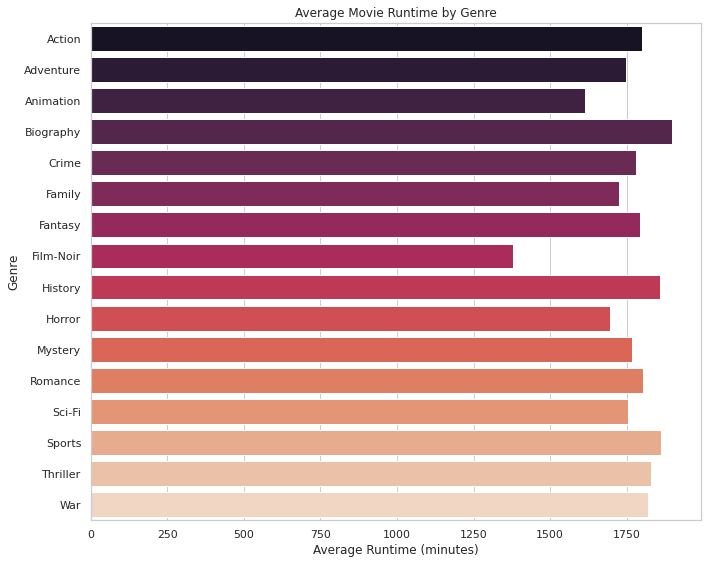

```python
# Step 1: Ensure 'runtime' is treated as a string and convert runtime to minutes
df['runtime'] = df['runtime'].astype(str)  # Convert to string if not already
df['runtime_minutes'] = df['runtime'].str.extract(r'(\d+):(\d+):(\d+)').apply(
    lambda x: int(x[1]) * 60 + int(x[2]), axis=1)

# Step 2: Calculate average runtime by genre
average_runtime_by_genre = df.groupby('genre')['runtime_minutes'].mean()
sns.set(style="whitegrid", rc={"figure.figsize": (10, 8)})

# Create a bar plot
sns.barplot(
    x=average_runtime_by_genre.values,
    y=average_runtime_by_genre.index,
    palette="rocket"
)

# Labeling the axes and title
plt.xlabel('Average Runtime (minutes)')
plt.ylabel('Genre')
plt.title('Average Movie Runtime by Genre')

# Adjust layout to not cut off labels or titles and display the plot
plt.tight_layout()
plt.show()
```

## Highest rated movies by year on Imdb

Creating a new dataframe with respect to ratings and find the highest rating for each year

```python
import pandas as pd

df = df.sort_values(by='year', ascending=False)

# Create an empty DataFrame with the same columns as df
highest_rated_movies = pd.DataFrame(columns=df.columns)

# Loop through each unique year in the 'year' column
for year in df['year'].unique():
    df_year = df[df['year'] == year]  # Filter by year
    if not df_year.empty:  # Check if the resulting DataFrame is not empty
        df_year_sorted = df_year.sort_values(by='rating', ascending=False)  # Sort by rating
        highest_rated_movie = df_year_sorted.iloc[0]  # Get the row with the highest rating
        # Append the row to the new DataFrame using concat
        highest_rated_movies = pd.concat([highest_rated_movies, pd.DataFrame([highest_rated_movie])], ignore_index=True)

# Remove rows where 'rating' might be NaN
highest_rated_movies = highest_rated_movies.dropna(subset=['rating'])

# Reset the index of the new DataFrame
highest_rated_movies.reset_index(drop=True, inplace=True)

# Display the DataFrame containing the highest rated movies by year
highest_rated_movies
```

|  | movie_name | year | certificate | runtime | genre | rating | description | director | star | votes | gross(in $) | runtime_minutes |
| --- | --- | --- | --- | --- | --- | --- | --- | --- | --- | --- | --- | --- |
| 0 | The Universal Quest | 2023 | NaN | 0 days 02:25:00 | Adventure | 10.0 | "The Universal Quest" is a sci-fi epic that ta... | Juwel Chowdhury | Juwel Chowdhury, , Ricky Riyaf | 6.0 | NaN | 1500 |
| 1 | Love Mein | 2022 | NaN | 0 days 01:00:00 | Action | 10.0 | This is 2016's love story where the only daugh... | Kumud Pant | Kumud Pant, , Pooja Kimaya, , Atul Sharma, , B... | 6.0 | NaN | 0 |
| 2 | Low Heat | 2021 | NaN | 0 days 00:48:00 | Action | 9.9 | The foul mouth quick quipping Jamal becomes in... | John Carroll DeShazier | Clinton D. Walker, , Dustin Bennett, , Ricardo... | 7.0 | NaN | 2880 |
| 3 | The Puzzling Secret | 2020 | NaN | 0 days 02:50:00 | Mystery | 10.0 | Add a Plot | Juwel Chowdhury | Juwel Chowdhury, , Ricky Riyaf | 6.0 | NaN | 3000 |
| 4 | Journey of Eternity | 2019 | NaN | 0 days 01:40:00 | History | 10.0 | After his beloved fiancé was forcibly taken aw... | Frank Gilbert | Abee Sargis, , Tarik Akreyî, , Kadhim Al-Qurai... | 9.0 | NaN | 2400 |
| ... | ... | ... | ... | ... | ... | ... | ... | ... | ... | ... | ... | ... |
| 114 | The Fairylogue and Radio-Plays | 1908 | NaN | 0 days 02:00:00 | Fantasy | 5.2 | L. Frank Baum would appear in a white suit and... | Francis Boggs, , Otis Turner | L. Frank Baum, , Frank Burns, , George E. Wils... | 67.0 | NaN | 0 |
| 115 | Life and Passion of Christ | 1907 | Not Rated | 0 days 00:45:00 | History | 6.7 | Depicting well-known incidents in the life of ... | Ferdinand Zecca | nan | 60.0 | NaN | 2700 |
| 116 | The Story of the Kelly Gang | 1906 | Not Rated | 0 days 01:10:00 | History | 6.0 | Story of Ned Kelly, an infamous 19th-century A... | Charles Tait | Elizabeth Tait, , John Tait, , Nicholas Brierl... | 810.0 | NaN | 600 |
| 117 | The Passion Play | 1903 | NaN | 0 days 00:45:00 | Biography | 6.5 | The story of Jesus Christ from the proclamatio... | Lucien Nonguet, , Ferdinand Zecca | Madame Moreau, , Monsieur Moreau | 575.0 | NaN | 2700 |
| 118 | Miss Jerry | 1894 | NaN | 0 days 00:45:00 | Romance | 5.3 | The adventures of a female reporter in the 1890s. | Alexander Black | Blanche Bayliss, , William Courtenay, , Chaunc... | 204.0 | NaN | 2700 |

119 rows × 12 columns

### Top rated movie of each year for the last 10 years

```python
top_Rmovies = highest_rated_movies.head(10)
top_Rmovies = top_Rmovies[['movie_name', 'director', 'genre', 'rating', 'year']]
top_Rmovies
```

|  | movie_name | director | genre | rating | year |
| --- | --- | --- | --- | --- | --- |
| 0 | The Universal Quest | Juwel Chowdhury | Adventure | 10.0 | 2023 |
| 1 | Love Mein | Kumud Pant | Action | 10.0 | 2022 |
| 2 | Low Heat | John Carroll DeShazier | Action | 9.9 | 2021 |
| 3 | The Puzzling Secret | Juwel Chowdhury | Mystery | 10.0 | 2020 |
| 4 | Journey of Eternity | Frank Gilbert | History | 10.0 | 2019 |
| 5 | The Trees of the East | Mike Ellwood | Thriller | 9.8 | 2018 |
| 6 | I Found My Heart in Sante Fe | Bona Fajardo | Romance | 9.8 | 2017 |
| 7 | My Friend Violet | Matthew S. Robinson | Thriller | 9.6 | 2016 |
| 8 | Heavy Makeup | Chris Morrissey | Horror | 9.6 | 2015 |
| 9 | The Killer Monroes | Joe Lujan, , Sharry Flaherty | Thriller | 9.6 | 2014 |

## Highest Voted movies on Imdb by year

Create a new dataframe with the highest voted movies on Imdb

```python
# Sort the DataFrame by 'year' descending to process the latest year first
df = df.sort_values(by='year', ascending=False)

# Create an empty DataFrame with the same columns as df for storing results
highest_voted_movies = pd.DataFrame(columns=df.columns)

# Loop through each unique year in the 'year' column
for year in df['year'].unique():
    # Filter the DataFrame by year
    df_year = df[df['year'] == year]
    # Check if the resulting DataFrame is not empty
    if not df_year.empty:
        # Sort the yearly DataFrame by 'votes' in descending order to find the highest voted movie
        df_year_sorted = df_year.sort_values(by='votes', ascending=False)
        # Get the row with the highest votes
        highest_voted_movie = df_year_sorted.iloc[0]
        # Append the row to the new DataFrame using concat
        highest_voted_movies = pd.concat([highest_voted_movies, highest_voted_movie.to_frame().T])

# Reindex
highest_voted_movies= highest_voted_movies.dropna(subset=['votes'])
highest_voted_movies.reset_index(drop=True, inplace=True)

# Display the DataFrame containing the highest voted movies by year
highest_voted_movies
```

|  | movie_name | year | certificate | runtime | genre | rating | description | director | star | votes | gross(in $) | runtime_minutes |
| --- | --- | --- | --- | --- | --- | --- | --- | --- | --- | --- | --- | --- |
| 0 | Pathaan | 2023 | Not Rated | 0 days 02:26:00 | Thriller | 6.6 | An Indian spy takes on the leader of a group o... | Siddharth Anand | Shah Rukh Khan, , Deepika Padukone, , John Abr... | 120080.0 | NaN | 1560 |
| 1 | The Batman | 2022 | PG-13 | 0 days 02:56:00 | Action | 7.8 | When a sadistic serial killer begins murdering... | Matt Reeves | Robert Pattinson, , Zoë Kravitz, , Jeffrey Wri... | 672146.0 | NaN | 3360 |
| 2 | Spider-Man: No Way Home | 2021 | PG-13 | 0 days 02:28:00 | Sci-Fi | 8.2 | With Spider-Man's identity now revealed, Peter... | Jon Watts | Tom Holland, , Zendaya, , Benedict Cumberbatch... | 770509.0 | 804747988.0 | 1680 |
| 3 | Tenet | 2020 | PG-13 | 0 days 02:30:00 | Sci-Fi | 7.3 | Armed with only one word, Tenet, and fighting ... | Christopher Nolan | John David Washington, , Robert Pattinson, , E... | 516838.0 | 58456624.0 | 1800 |
| 4 | Joker | 2019 | R | 0 days 02:02:00 | Thriller | 8.4 | A mentally troubled stand-up comedian embarks ... | Todd Phillips | Joaquin Phoenix, , Robert De Niro, , Zazie Bee... | 1310698.0 | 335451311.0 | 120 |
| ... | ... | ... | ... | ... | ... | ... | ... | ... | ... | ... | ... | ... |
| 114 | The Fairylogue and Radio-Plays | 1908 | NaN | 0 days 02:00:00 | Adventure | 5.2 | L. Frank Baum would appear in a white suit and... | Francis Boggs, , Otis Turner | L. Frank Baum, , Frank Burns, , George E. Wils... | 67.0 | NaN | 0 |
| 115 | Life and Passion of Christ | 1907 | Not Rated | 0 days 00:45:00 | Biography | 6.6 | Depicting well-known incidents in the life of ... | Ferdinand Zecca | nan | 61.0 | NaN | 2700 |
| 116 | The Story of the Kelly Gang | 1906 | Not Rated | 0 days 01:10:00 | Biography | 6.0 | Story of Ned Kelly, an infamous 19th-century A... | Charles Tait | Elizabeth Tait, , John Tait, , Nicholas Brierl... | 818.0 | NaN | 600 |
| 117 | The Passion Play | 1903 | NaN | 0 days 00:45:00 | Biography | 6.5 | The story of Jesus Christ from the proclamatio... | Lucien Nonguet, , Ferdinand Zecca | Madame Moreau, , Monsieur Moreau | 575.0 | NaN | 2700 |
| 118 | Miss Jerry | 1894 | NaN | 0 days 00:45:00 | Romance | 5.3 | The adventures of a female reporter in the 1890s. | Alexander Black | Blanche Bayliss, , William Courtenay, , Chaunc... | 204.0 | NaN | 2700 |

119 rows × 12 columns

### Top most voted movie by year for the last 10 years

```python
top_Vmovies = highest_voted_movies.head(10)
top_Vmovies = top_Vmovies[['movie_name', 'director', 'genre', 'votes', 'year']]
top_Vmovies
```

|  | movie_name | director | genre | votes | year |
| --- | --- | --- | --- | --- | --- |
| 0 | Pathaan | Siddharth Anand | Thriller | 120080.0 | 2023 |
| 1 | The Batman | Matt Reeves | Action | 672146.0 | 2022 |
| 2 | Spider-Man: No Way Home | Jon Watts | Sci-Fi | 770509.0 | 2021 |
| 3 | Tenet | Christopher Nolan | Sci-Fi | 516838.0 | 2020 |
| 4 | Joker | Todd Phillips | Thriller | 1310698.0 | 2019 |
| 5 | Avengers: Infinity War | Anthony Russo, , Joe Russo | Sci-Fi | 1095314.0 | 2018 |
| 6 | Logan | James Mangold | Sci-Fi | 772831.0 | 2017 |
| 7 | Deadpool | Tim Miller | Action | 1049045.0 | 2016 |
| 8 | Mad Max: Fury Road | George Miller | Sci-Fi | 1013611.0 | 2015 |
| 9 | Interstellar | Christopher Nolan | Sci-Fi | 1859284.0 | 2014 |

## What is the relationship between votes and ratings?

I wanted to plot the relationship between total votes and ratings and how they are/are not different. Votes signifies how popular a movie may be. Ratings signifies how good the movie may be.

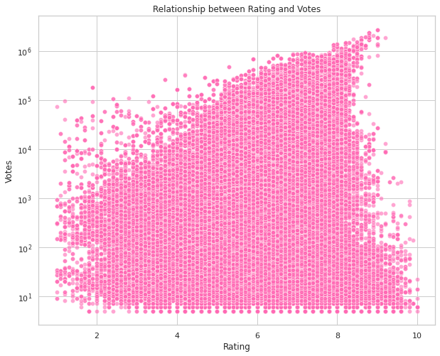

```python
# Cleaning
df['rating'] = pd.to_numeric(df['rating'], errors='coerce')  # Convert rating to numeric, coercing errors
df['votes'] = pd.to_numeric(df['votes'], errors='coerce')  # Convert votes to numeric, coercing errors
df.dropna(subset=['rating', 'votes'], inplace=True)  # Drop rows where either value is NaN

# Visualization
plt.figure(figsize=(10, 8))
sns.scatterplot(x='rating', y='votes', data=df, alpha=0.6, color= 'hotpink')
plt.title('Relationship between Rating and Votes')
plt.xlabel('Rating')
plt.ylabel('Votes')
plt.yscale('log')
plt.grid(True)
plt.show()
```

## Identifying a correlation between rates, votes and gross earnings of a movie.

How are all 3 of these factors distributed and related? This helps for an industry analysis. I chose boxplot to plot these 3 variables from df to see their distribution.

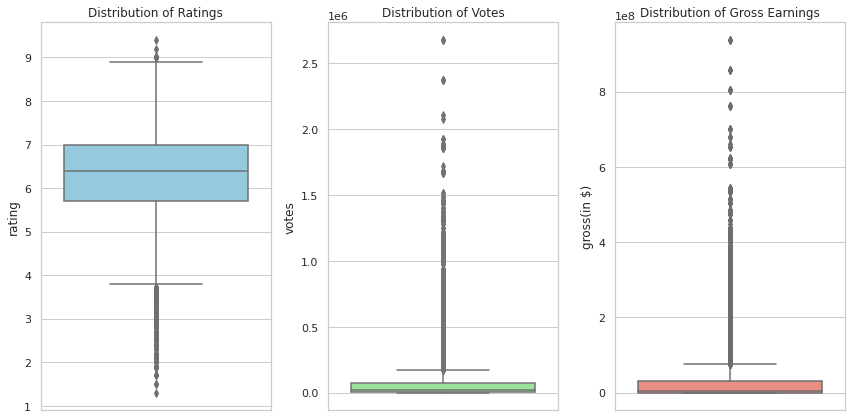

```python
import seaborn as sns
import matplotlib.pyplot as plt
import pandas as pd

# Assuming df is your DataFrame containing the movie data

# First, let's ensure the necessary data columns are in the right format and clean:
df['rating'] = pd.to_numeric(df['rating'], errors='coerce')  # Convert to numeric, handling non-numeric gracefully
df['votes'] = pd.to_numeric(df['votes'], errors='coerce')
df['gross(in $)'] = pd.to_numeric(df['gross(in $)'], errors='coerce')

# Drop rows with NaN values in these columns for cleaner visualization
df = df.dropna(subset=['rating', 'votes', 'gross(in $)'])

# Create box plots for ratings, votes, and gross earnings
plt.figure(figsize=(12, 6))
plt.subplot(1, 3, 1)
sns.boxplot(y='rating', data=df, color='skyblue')
plt.title('Distribution of Ratings')

plt.subplot(1, 3, 2)
sns.boxplot(y='votes', data=df, color='lightgreen')
plt.title('Distribution of Votes')

plt.subplot(1, 3, 3)
sns.boxplot(y='gross(in $)', data=df, color='salmon')
plt.title('Distribution of Gross Earnings')

plt.tight_layout()
plt.show()
```

## Most popular actors of all time

Visualization created using the stars column cleaned and stored in a separate column with each star being stored separately with the total number of times they occur in a datset.

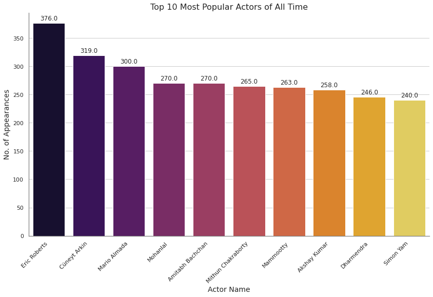

```python
import matplotlib.pyplot as plt
import numpy as np  # For generating a range of colors

# Assuming top_actors is already defined as the top 10 entries from star_counts_df
top_actors = star_counts_df.head(10)

# Create the bar plot with each bar having a different color
plt.figure(figsize=(14, 8))  # Make the figure larger: width=14 inches, height=8 inches
barplot = sns.barplot(x='Star Name', y='Occurrences', data=top_actors, palette="inferno")

# Set the x-ticks to be more readable
plt.xticks(rotation=45, ha='right')  # ha='right' helps with alignment of long names

# Setting labels and title
plt.xlabel("Actor Name", fontsize=14)  # Increase font size for clarity
plt.ylabel("No. of Appearances", fontsize=14)
plt.title("Top 10 Most Popular Actors of All Time", fontsize=16)

# Adding value labels on each bar
for p in barplot.patches:
    barplot.annotate(format(p.get_height(), '.1f'),
                     (p.get_x() + p.get_width() / 2., p.get_height()),
                     ha = 'center', va = 'center',
                     xytext = (0, 9),
                     textcoords = 'offset points')

# Remove background color
plt.gca().set_facecolor('none')  # Set the background color to none (transparent within the figure)
plt.gca().spines['top'].set_visible(False)  # Hide the top spine
plt.gca().spines['right'].set_visible(False)  # Hide the right spine
plt.gca().spines['left'].set_color('gray')  #  change the color of the left spine to gray
plt.gca().spines['bottom'].set_color('gray')  #  change the color of the bottom spine to gray

# Show the plot
plt.show()
```

## Most popular directors of all time, by number of movies directed

Visualization created using the directors column cleaned and stored in a separate column with each director being stored separately with the total number of times they occur in a datset.

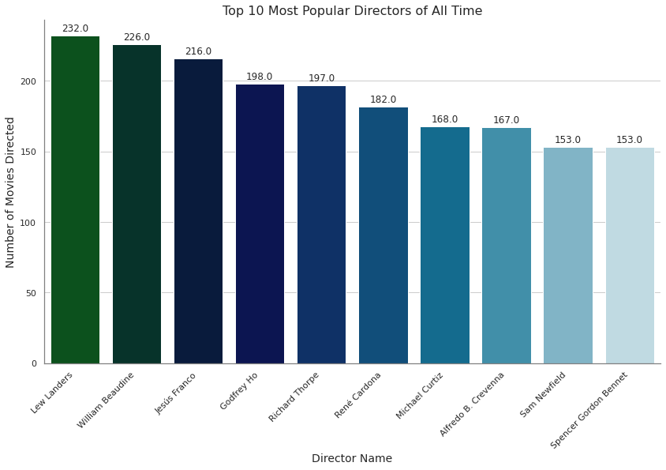

```python
top_dir = director_counts_df.head(10)

# Create the bar plot with each bar having a different color
plt.figure(figsize=(14, 8))
barplot = sns.barplot(x='Director Name', y='Occurrences', data=top_dir, palette="ocean")

# Set the x-ticks to be more readable
plt.xticks(rotation=45, ha='right')

# Setting labels and title
plt.xlabel("Director Name", fontsize=14)  # Increase font size for clarity
plt.ylabel("Number of Movies Directed", fontsize=14)
plt.title("Top 10 Most Popular Directors of All Time", fontsize=16)

# Adding value labels on each bar
for p in barplot.patches:
    barplot.annotate(format(p.get_height(), '.1f'),
                     (p.get_x() + p.get_width() / 2., p.get_height()),
                     ha = 'center', va = 'center',
                     xytext = (0, 9),
                     textcoords = 'offset points')

# Remove background color
plt.gca().set_facecolor('none')  # Set the background color to none (transparent within the figure)
plt.gca().spines['top'].set_visible(False)  # Hide the top spine
plt.gca().spines['right'].set_visible(False)  # Hide the right spine
plt.gca().spines['left'].set_color('gray')  #  change the color of the left spine to gray
plt.gca().spines['bottom'].set_color('gray')  #  change the color of the bottom spine to gray

# Show the plot
plt.show()
```

## Get the highest grossing movie for each year

```python
# Initialize an empty DataFrame with the same columns as df
highest_revenue_movies = pd.DataFrame(columns=df.columns)

# Iterate through each unique year in the DataFrame, excluding the years 2025 and 2024
for year in df['year'].unique():
    if year not in [2025, 2024]:  # Exclude the specified years
        df_year = df[df['year'] == year]  # Filter the DataFrame by the current year
        if not df_year.empty:  # Check if the resulting DataFrame is not empty
            # Sort by 'gross(in $)' in descending order to find the movie with the highest revenue
            df_year_sorted = df_year.sort_values(by='gross(in $)', ascending=False)
            highest_revenue_movie = df_year_sorted.iloc[0]  # Get the first row, the highest revenue
            # Create a DataFrame from the highest revenue movie and concatenate it with the main DataFrame
            highest_revenue_movies = pd.concat([highest_revenue_movies, highest_revenue_movie.to_frame().T])

columns_to_drop = ['description', 'director','star']
highest_revenue_movies.drop(columns=columns_to_drop, inplace=True)

# Sort the DataFrame by year in descending order
highest_revenue_movies = highest_revenue_movies.sort_values(by='year', ascending=False)
highest_revenue_movies = highest_revenue_movies.reset_index(drop=True)

highest_revenue_movies
```

|  | movie_name | year | certificate | runtime | genre | rating | votes | gross(in $) | runtime_minutes |
| --- | --- | --- | --- | --- | --- | --- | --- | --- | --- |
| 0 | Minions: The Rise of Gru | 2022 | PG | 0 days 01:27:00 | Animation | 6.5 | 70007.0 | 369695210.0 | 1620 |
| 1 | Spider-Man: No Way Home | 2021 | PG-13 | 0 days 02:28:00 | Adventure | 8.2 | 770492.0 | 804747988.0 | 1680 |
| 2 | Bad Boys for Life | 2020 | R | 0 days 02:04:00 | Action | 6.5 | 163933.0 | 206305244.0 | 240 |
| 3 | Avengers: Endgame | 2019 | PG-13 | 0 days 03:01:00 | Action | 8.4 | 1148100.0 | 858373000.0 | 60 |
| 4 | Black Panther | 2018 | PG-13 | 0 days 02:14:00 | Adventure | 7.3 | 785813.0 | 700059566.0 | 840 |
| ... | ... | ... | ... | ... | ... | ... | ... | ... | ... |
| 104 | A Romance of the Redwoods | 1917 | Not Rated | 0 days 01:10:00 | History | 6.1 | 835.0 | 424719.0 | 600 |
| 105 | 20,000 Leagues Under the Sea | 1916 | Passed | 0 days 01:25:00 | Adventure | 6.1 | 1860.0 | 8000000.0 | 1500 |
| 106 | The Birth of a Nation | 1915 | TV-PG | 0 days 03:15:00 | War | 6.2 | 25213.0 | 10000000.0 | 900 |
| 107 | The Squaw Man | 1914 | Not Rated | 0 days 01:14:00 | Romance | 5.7 | 995.0 | 533446.0 | 840 |
| 108 | Traffic in Souls | 1913 | TV-PG | 0 days 01:28:00 | Crime | 6.0 | 696.0 | 430000.0 | 1680 |

109 rows × 9 columns

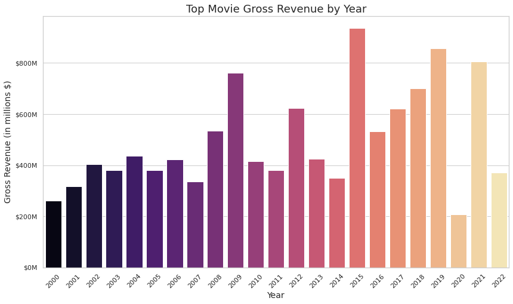

```python
# Create the bar chart using seaborn with a larger figure size for better visibility
top_grossing = highest_revenue_movies.sort_values('year', ascending=False).head(23)
plt.figure(figsize=(14, 8))  # Set the figure size (width, height) in inches
sns.set(style="whitegrid")  # Apply the whitegrid style for a clean background with gridlines

# Create the bar plot
ax = sns.barplot(x='year', y='gross(in $)', data=top_grossing, palette="magma")

# Format y-axis tick labels in millions and adjust label format to show commas for thousands
ax.yaxis.set_major_formatter(mtick.FuncFormatter(lambda x, _: f'${x/1e6:,.0f}M'))

# Set the title and axis labels with increased font size for clarity
ax.set_title('Top Movie Gross Revenue by Year', fontsize=18)
ax.set_xlabel('Year', fontsize=14)
ax.set_ylabel('Gross Revenue (in millions $)', fontsize=14)

# Rotate the x-axis labels for better readability
plt.xticks(rotation=45)

#Adjust the margins to ensure the x-axis labels are fully visible
plt.subplots_adjust(bottom=0.15)

# Display the plot
plt.show()
```

## What certificates do high revenue movies earn more commonly?

What kind of movies are most watched/most popular?

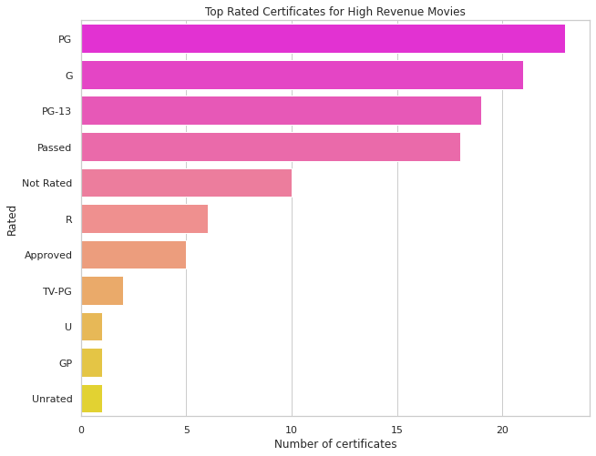

```python
certificate_counts_high_revenue = highest_revenue_movies['certificate'].value_counts().sort_values(ascending=False)

certificate_counts_high_revenue_df = certificate_counts_high_revenue.to_frame().reset_index()
certificate_counts_high_revenue_df.columns = ['certificate', 'count']

plt.figure(figsize=(10, 8))
sns.barplot(x='count', y='certificate', data=certificate_counts_high_revenue_df, palette="spring")
plt.title('Top Rated Certificates for High Revenue Movies')
plt.xlabel('Number of certificates')
plt.ylabel('Rated')
plt.show()
```

## What genre of movie grosses the highest?

I am curious to see what genre of movie grosses the highest by plotting the total gross values for each genre using a bar graph and using groupby to calculate total gross for each genre

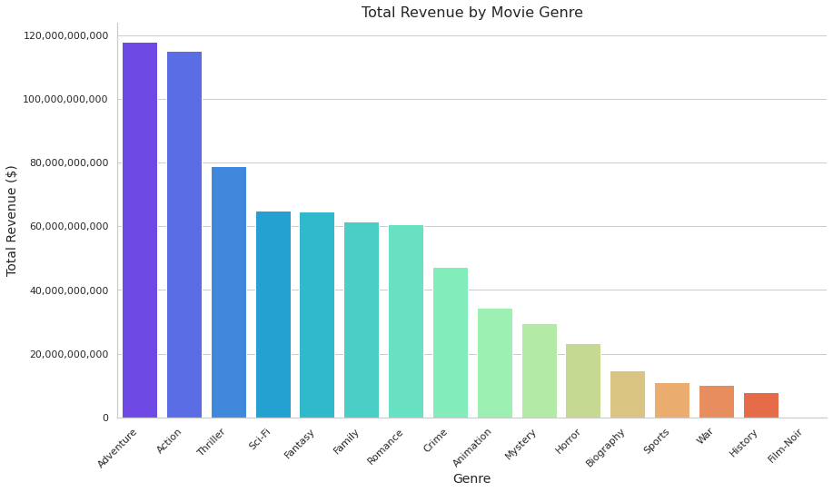

```python
# Group by 'genre' and sum up the revenues
genre_revenue = df.groupby('genre')['gross(in $)'].sum().reset_index()

# Sort the results by revenue in descending order
genre_revenue_sorted = genre_revenue.sort_values('gross(in $)', ascending=False)

# Create the bar plot
plt.figure(figsize=(14, 8))
sns.set(style="whitegrid")
ax = sns.barplot(x='genre', y='gross(in $)', data=genre_revenue_sorted, palette="rainbow")

# Rotate x-axis labels for better readability
plt.xticks(rotation=45, ha="right")

# Set plot title and axis labels
plt.title('Total Revenue by Movie Genre', fontsize=16)
plt.xlabel('Genre', fontsize=14)
plt.ylabel('Total Revenue ($)', fontsize=14)

# Format the y-axis as currency
ax.get_yaxis().set_major_formatter(
    plt.matplotlib.ticker.FuncFormatter(lambda x, p: format(int(x), ','))
)

# Remove the right and top spines
sns.despine()

# Show the plot
plt.show()
```

## Who is the best director?

I can explore who is the best director by getting average votes and average ratings for each director. I will only consider them for further analysis if they have more than 20 movies in order to make the calculations more fair.

```python
# Create a copy of the original DataFrame
df_director = df_copy[['director', 'rating', 'votes']].copy()

# Split 'director' column into individual directors
df_director['director'] = df_director['director'].str.split('\n')

# Explode the DataFrame to create separate rows for each director
df_director = df_director.explode('director')
df_director['director'] = df_director['director'].str.replace(',', '')

# Count occurrences of each director
director_occurrences = df_director['director'].value_counts()

# Add 'occurrences' column to the DataFrame
df_director['occurrences'] = df_director['director'].map(director_occurrences)

# Group by director and calculate total ratings and total votes
director_totals = df_director.groupby('director').agg({'rating': 'sum', 'votes': 'sum'}).reset_index()
director_totals.columns = ['director', 'total_ratings', 'total_votes']
df_director = df_director[df_director['occurrences'] >= 20 ]
# Merge the totals back to the original DataFrame
df_director = pd.merge(df_director, director_totals, on='director', how='left')

# Calculate average ratings and average votes
df_director['average_ratings'] = df_director['total_ratings'] / df_director['occurrences']
df_director['average_votes'] = df_director['total_votes'] / df_director['occurrences']

# Display the resulting DataFrame
df_director
```

|  | director | rating | votes | occurrences | total_ratings | total_votes | average_ratings | average_votes |
| --- | --- | --- | --- | --- | --- | --- | --- | --- |
| 0 | James Cameron | 7.8 | 295119.0 | 37.0 | 182.3 | 15786815.0 | 4.927027 | 426670.675676 |
| 1 | Jean-François Richet | 6.5 | 26220.0 | 22.0 | 147.7 | 779414.0 | 6.713636 | 35427.909091 |
| 2 | Louis Leterrier | NaN | NaN | 24.0 | 128.7 | 5619511.0 | 5.362500 | 234146.291667 |
| 3 | Russell Mulcahy | 5.6 | 9026.0 | 48.0 | 263.9 | 1623486.0 | 5.497917 | 33822.625000 |
| 4 | Matt Reeves | 7.8 | 672146.0 | 24.0 | 151.8 | 7377902.0 | 6.325000 | 307412.583333 |
| ... | ... | ... | ... | ... | ... | ... | ... | ... |
| 78731 | Christy Cabanne | 5.5 | 33.0 | 121.0 | 578.1 | 28498.0 | 4.777686 | 235.520661 |
| 78732 | Irving Pichel | 4.5 | 21.0 | 65.0 | 407.3 | 60346.0 | 6.266154 | 928.400000 |
| 78733 | Miguel Iglesias | 6.2 | 46.0 | 24.0 | 112.2 | 2889.0 | 4.675000 | 120.375000 |
| 78734 | Thomas Bentley | 5.0 | 79.0 | 21.0 | 54.6 | 1856.0 | 2.600000 | 88.380952 |
| 78735 | George Blair | 6.3 | 40.0 | 96.0 | 538.9 | 7647.0 | 5.613542 | 79.656250 |

78736 rows × 8 columns

### Best director by average rating

```python
#geting the mean of average ratings and votes of each director if they have multiple occurrences
director_avg_stats = df_director.groupby('director').agg({
    'average_ratings': 'mean',
    'average_votes': 'mean'
}).reset_index()

# Sort the DataFrame by average_ratings in descending order
highest_rated_directors = director_avg_stats.sort_values(by='average_ratings', ascending=False)

# Display the resulting DataFrame
highest_rated_directors=highest_rated_directors.reset_index(drop =True)
highest_rated_directors
```

|  | director | average_ratings | average_votes |
| --- | --- | --- | --- |
| 0 | Haruo Sotozaki | 8.360000 | 16545.600000 |
| 1 | Quentin Tarantino | 8.071429 | 757350.523810 |
| 2 | Satyajit Ray | 8.059091 | 2381.227273 |
| 3 | Upendra | 7.935000 | 2144.450000 |
| 4 | Akira Kurosawa | 7.730769 | 49984.435897 |
| ... | ... | ... | ... |
| 2068 | Dmitriy Lazarev | 0.000000 | 0.000000 |
| 2069 | Ding M. De Jesus | 0.000000 | 0.000000 |
| 2070 | Rock Parsons | 0.000000 | 0.000000 |
| 2071 | Consuelo P. Osorio | 0.000000 | 0.000000 |
| 2072 | Drew Kochera | 0.000000 | 0.000000 |

2073 rows × 3 columns

### Best director by votes (popularity)

```python
#getting the mean of average ratings and votes of each director if they have multiple occurrences
director_avg_stats = df_director.groupby('director').agg({
    'average_ratings': 'mean',
    'average_votes': 'mean'
}).reset_index()

# Sort the DataFrame by average_ratings in descending order
highest_voted_directors = director_avg_stats.sort_values(by='average_votes', ascending=False)
highest_voted_directors=highest_voted_directors.reset_index(drop =True)
# Display the resulting DataFrame
highest_voted_directors
```

|  | director | average_ratings | average_votes |
| --- | --- | --- | --- |
| 0 | Christopher Nolan | 7.629032 | 1.211750e+06 |
| 1 | Quentin Tarantino | 8.071429 | 7.573505e+05 |
| 2 | Peter Jackson | 6.563636 | 6.447772e+05 |
| 3 | David Fincher | 6.181481 | 5.351790e+05 |
| 4 | J.J. Abrams | 7.245000 | 5.220088e+05 |
| ... | ... | ... | ... |
| 2068 | Hun Choi | 0.000000 | 0.000000e+00 |
| 2069 | Rock Parsons | 0.000000 | 0.000000e+00 |
| 2070 | Brando Improta | 0.000000 | 0.000000e+00 |
| 2071 | Roman Tramvay | 0.000000 | 0.000000e+00 |
| 2072 | Jim Ardent | 0.000000 | 0.000000e+00 |

2073 rows × 3 columns

## What is the relationship between highly voted and rated directors?

Do higher rated directors recieve higher votes? Is there some sort of bias when rating the movie of a highly rated director?

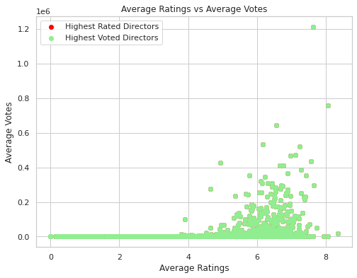

```python
import matplotlib.pyplot as plt

# Plot scatter plot of average ratings vs average votes
plt.figure(figsize=(8, 6))
plt.scatter(highest_rated_directors['average_ratings'], highest_rated_directors['average_votes'], color='red', label='Highest Rated Directors')
plt.scatter(highest_voted_directors['average_ratings'], highest_voted_directors['average_votes'], color='lightgreen', label='Highest Voted Directors')
plt.xlabel('Average Ratings')
plt.ylabel('Average Votes')
plt.title('Average Ratings vs Average Votes')
plt.legend()
plt.grid(True)

# Show the plot
plt.show()
```

## Relationship between run time and gross usd earned

I am curious to explore if a shorter movie means more revenue since people are more likely to watch something that takes less time.

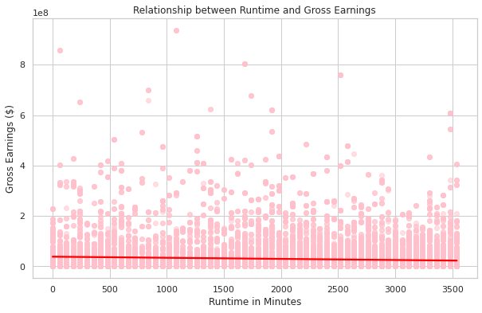

```python
# cleaning
df['gross(in $)'] = pd.to_numeric(df['gross(in $)'], errors='coerce')  # Convert gross to numeric, coercing errors to NaN
df.dropna(subset=['runtime_minutes', 'gross(in $)'], inplace=True)  # Drop rows where either value is NaN

# Visualization
plt.figure(figsize=(10, 6))
sns.regplot(x='runtime_minutes', y='gross(in $)', data=df, scatter_kws={'alpha':0.5, 'color':'pink'}, line_kws={'color':'red'})
plt.title('Relationship between Runtime and Gross Earnings')
plt.xlabel('Runtime in Minutes')
plt.ylabel('Gross Earnings ($)')
plt.grid(True)
plt.show()
```